# STA141 final project

### 5. Visual the change of overall neuron spike rate for each session

To better visualise these neural dynamics, we next plotted the neuron spike rates in each session – the ups and downs of neural activity across individual trials. Each plot represents the behaviour of the neuron over these trials, and we can see that the variability of spikes across sessions is much higher than that within sessions. Such variability likely results from the complex underlying neural processes. Sometimes, spike rates peak and trough in such a way that we can imagine these plots representing the neural encoding of sensory experiences or decisions.

Some of the patterns that remain consistent across sessions might represent shared neural mechanisms, while the unique patterns of fluctuations might be related to individual differences or session-specific nuances. These insights, along with our earlier findings, can facilitate a more personalised revising of our predictive models of neural responsiveness in the face of this tapestry of variability across sessions.

The graphics describes the change in each trial by session over time in the overall neuron spike rate. We used the function in R to plot the mean spike rate of the neuron against the number of trials in each session. The black lines denote real spike rates across the trials while the blue line indicates in smoothed trend across the trials

Each session shows a substantial degree of variability in spike rates across trials. The variability could be due to the natural dynamics of neuronal firing patterns, or could be responding to some variable associated with different stimuli that are presented on different trials. Despite this variability, there is also some kind of stability in the range of spike rates with most sessions varying between 0 to 3 spikes in a trial with an occasional higher value. This suggests that though each individual trial may be responding differently, the overall state of the system is operating at a stable level of activity. In some of the sessions, the smoothed trend lines show an upward or downward drift, but in most cases, these drift lines are so weak that they are not especially conspicuous and might suggest that there is not a strong systematic change in neuron spike-rate as the sessions go by. Outliers: It is possible to see the presence of some spikes that are higher than anything else in a session and could be a result when the neurons were undergoing some activity in excess of what is normal. Such instances would be useful to look deeper into the conditions that would have led to such high spikes in activity , some behavioural response from the mice or some other factor influencing the neuronal activity. Session-to-session comparison: A close look at the plots would reveal that the nature of variability and trends are not exactly the same across sessions and this suggests that the way in which the mice are kept, the experimental set-up or the stimuli provided to the mice have session-to-session variation and can impact neuronal spike rates.

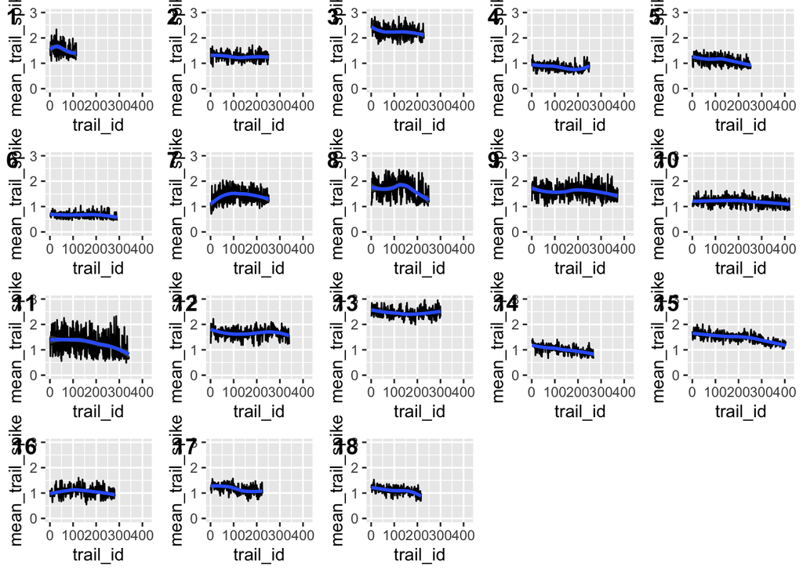